# lab2

#### Suppose that in a population, there is 1/3 chance that a given person has a mutation in some gene.

Define the probability of a person having the mutation.

```r
p_mutation <- 1/3
```

```r
p_value <- binom.test(x=12, n=30, p=p_mutation, "two.sided")$p.value
```

**P-value: 0.4429185**

A probability density function showing the distribution for observing exactly one to thirty people with the mutation.

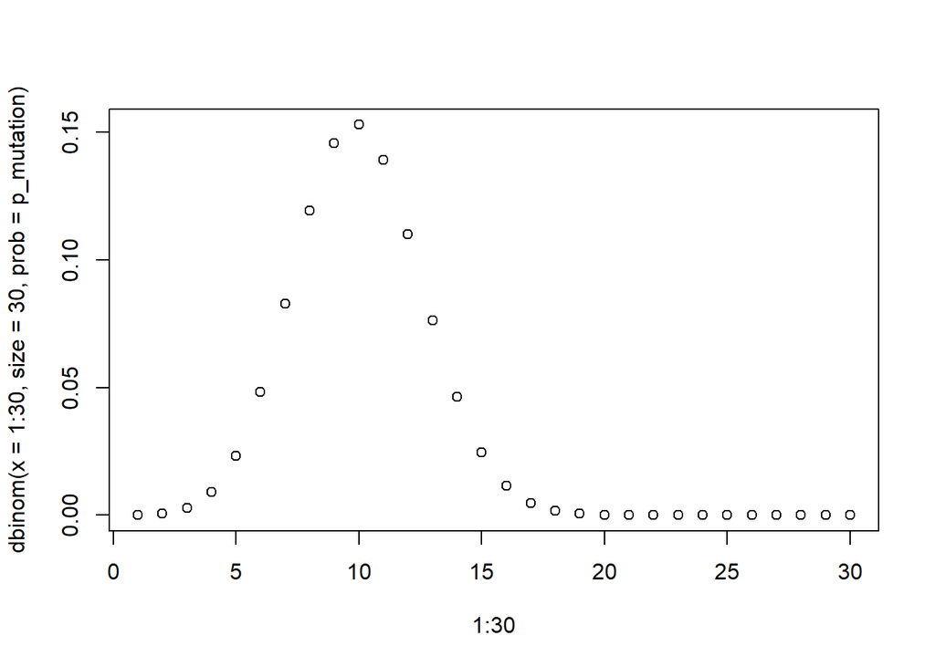

```r
plot(1:30, dbinom(x=1:30, size=30, prob=p_mutation))
```

The mean and variance for the expected number of people with the mutation are:

```r
expectedMean <- 30 * p_mutation
expectedVariance <- 30 * p_mutation * (1 - p_mutation)
```

**Expected mean: 10**  
**Expected variance: 6.67**

#### Suppose the background expected survival rate for a disease is 0.4. You are running a clinical trial and have 100 patients on a new drug. 47 patients die; 53 survive.

Define the given values.

```r
p_survival <- 0.4
n_total <- 100
n_dead <- 47
n_survived <- 53
```

A probability density function showing the number of patients that survive under the null hypothesis.

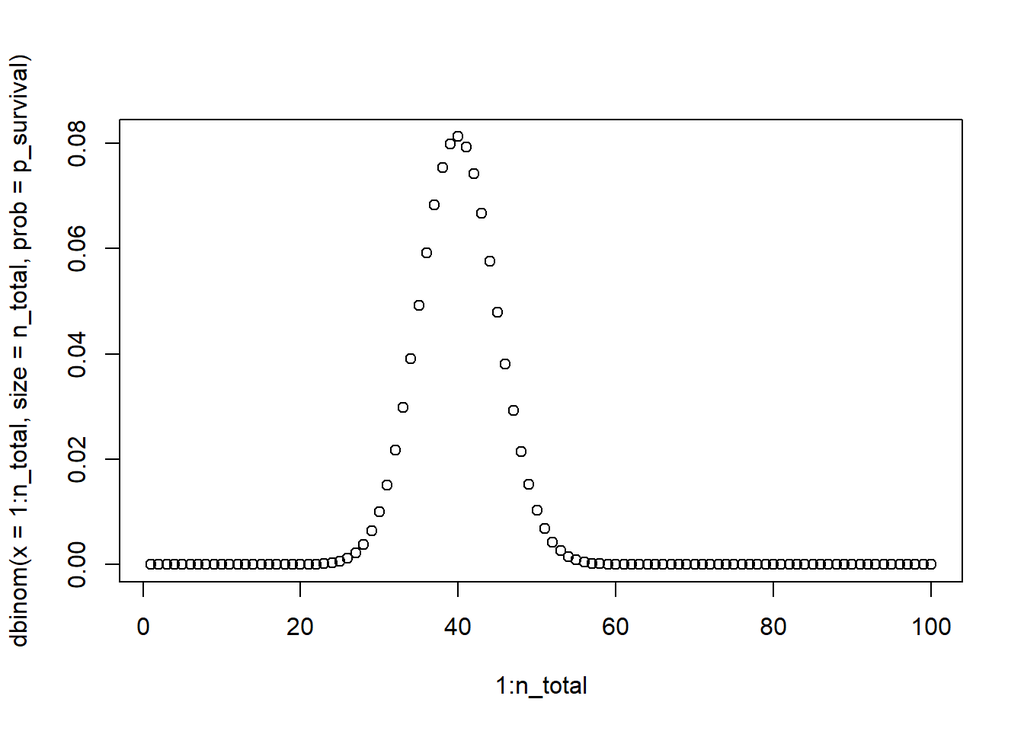

```r
plot(1:n_total, dbinom(x=1:n_total, size=n_total, prob=p_survival))
```

The p-value for a null hypothesis that the drug has no effect is:

```r
p_value <- binom.test(x=n_survived, n_total, p=p_survival, "two.sided")$p.value
```

**P-value: 0.0104**

Confirm by finding the two-sided tail area under the probability density function curve.

```r
expectedMean <- n_total * p_survival
deviation <- abs(expectedMean - n_survived)
densityDist <- dbinom(1:n_total, n_total, p_survival)
sum(densityDist[1:(expectedMean - deviation)]) + sum(densityDist[n_survived:n_total])
```

```
## [1] 0.01036108
```

The p-value for a null hypothesis that the drug does not improve survival is:

```r
p_value <-binom.test(x=n_survived, n_total, p=p_survival, "greater")$p.value
```

**P-value: 0.0058**

Confirm by finding the right-sided tail area under the probability density function curve.

```r
sum(densityDist[n_survived:n_total])
```

```
## [1] 0.005760648
```

#### simulate 1,000 experiments in which 10,000 patients are sampled with a 1/2 chance of seeing a mutation.

Define given values.

```r
n_experiments <- 1000
n_samples <- 10000
p_mutation <- 1/2
```

Perform simulation.

```r
mutation_observations <- rbinom(n_experiments, n_samples, p_mutation)
length(mutation_observations)
```

```
## [1] 1000
```

The expected and observed means and variances of the simulation vector are:

```r
expectedMean <- n_samples * p_mutation
observedMean <- mean(mutation_observations)
```

**Expected mean: 5000**  
**Observed mean: 5001**

```r
expectedVariance <- n_samples * p_mutation * (1 - p_mutation)
observedVariance <- var(mutation_observations)
```

**Expected variance: 2500**  
**Observed variance: 2410**

*Additional exploration:* As expected, the number of patients with the mutation visually centers around the expected mean of 5000.

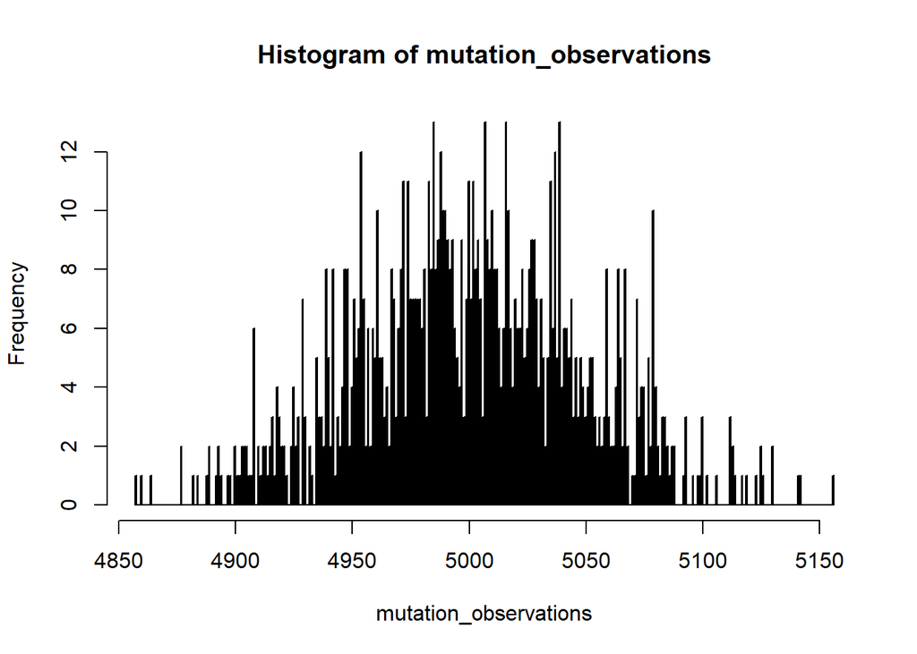

```r
hist(mutation_observations, breaks = 1000)
```

For each simulated experiment, calculate a p-value for the null hypothesis that the frequency of the mutated allele in the population is 1/2.

Define a function for this purpose.

```r
get_p_values <- function(pval) {
  p_values <- vector()
  for (i in 1:length(mutation_observations)) {
    p_values[i] = binom.test(mutation_observations[i], n_samples, p=pval, "two.sided")$p.value
  }
  return(p_values)
}
```

```r
p_values <- get_p_values(p_mutation)
head(p_values)
```

```
## [1] 0.49019608 0.31249521 0.81809318 0.69653858 0.55519280 0.01277043
```

A histogram showing the frequencies of the p-values calculated above.

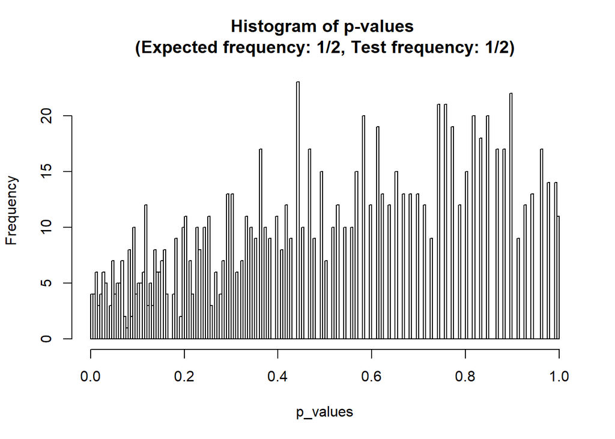

```r
hist(p_values, breaks=200, main="Histogram of p-values \n(Expected frequency: 1/2, Test frequency: 1/2)")
```

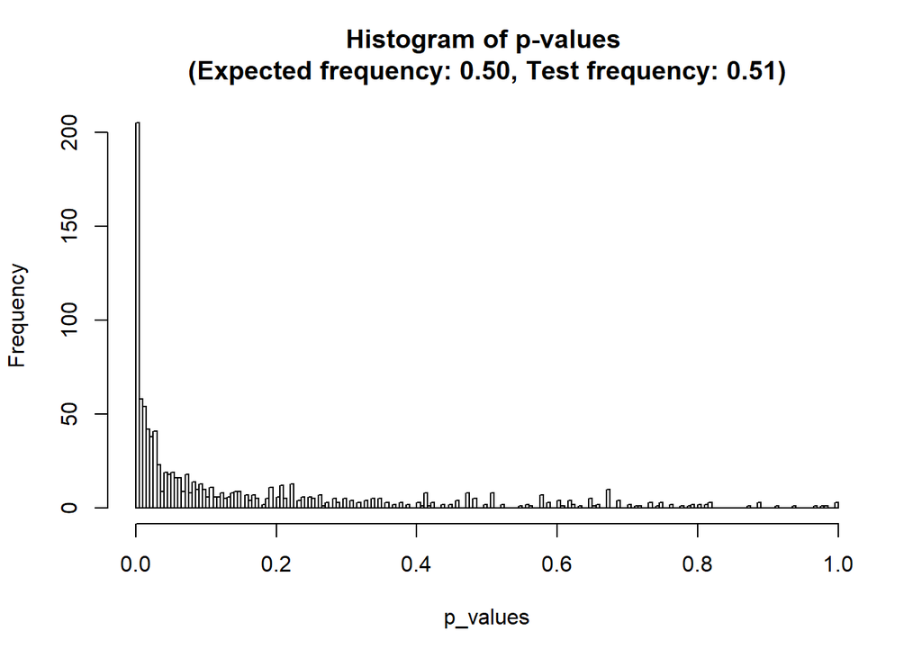

```r
p_values <- get_p_values(pval=0.51)
hist(p_values, breaks=200, main="Histogram of p-values \n(Expected frequency: 0.50, Test frequency: 0.51)")
```